# Chapter04

Boylad

2019/4/17

### 4.1

模拟得到1000个参数为0.3的贝努里分布随机数, 并用图示表示出来.

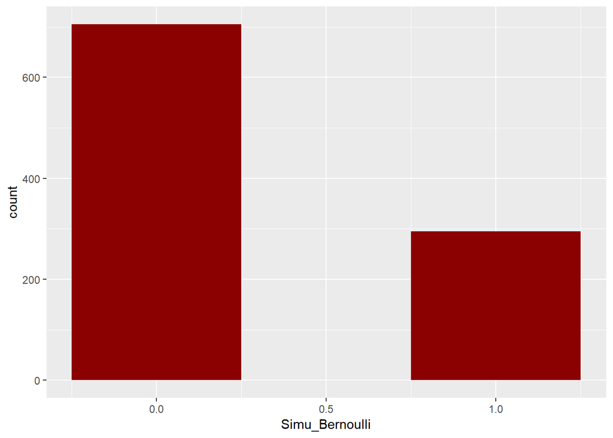

1000个服从 B(1,0.3) 的随机数柱状图

```r
library(ggplot2)
set.seed(201904)
Simu_Bernoulli <- rbinom(n = 1000, size = 1, prob = 0.3)
ggplot(mapping =  aes(x = Simu_Bernoulli)) +
  geom_histogram(bins = 2, binwidth = 0.5, fill = 'dark red')
```

### 4.2

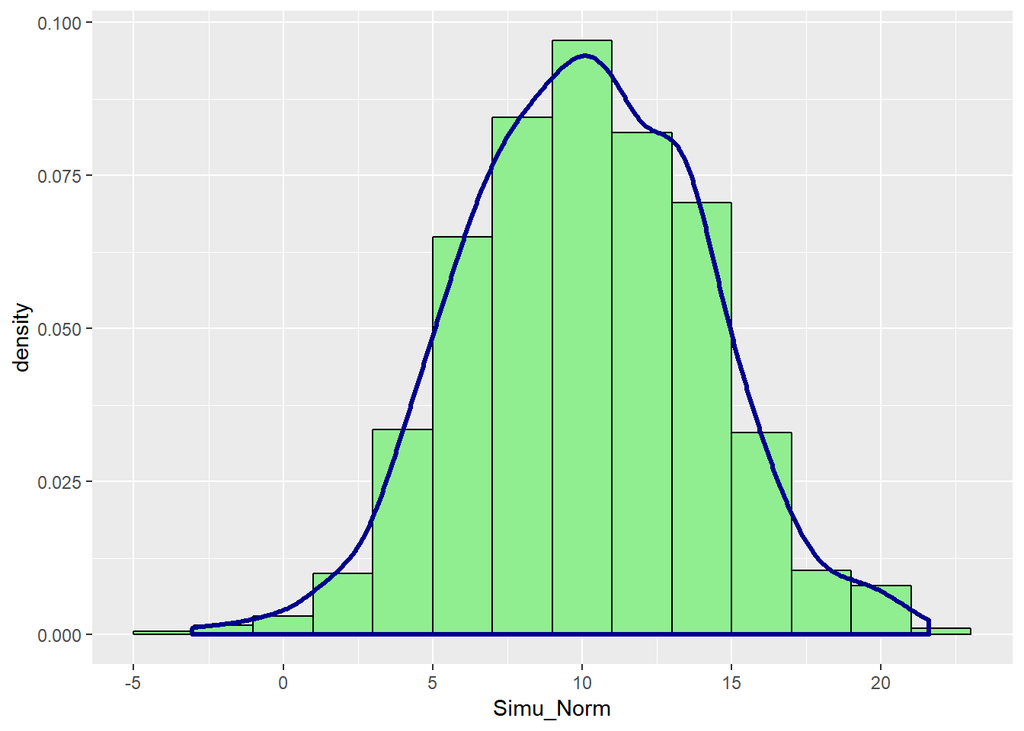

```r
set.seed(201904)
Simu_Norm <- rnorm(n = 1000, mean = 10, sd = 4)
ggplot(mapping =  aes(x = Simu_Norm)) +
  geom_histogram(mapping =  aes(y=..density..), binwidth = 2,
               color = 'black', fill = 'lightgreen') +
  geom_density(size = 1.1, color = 'darkblue')
```

### 4.3

模拟得到三个t分布混合而成的样本, 用直方图呈现数据的分布并添加核密度曲线.

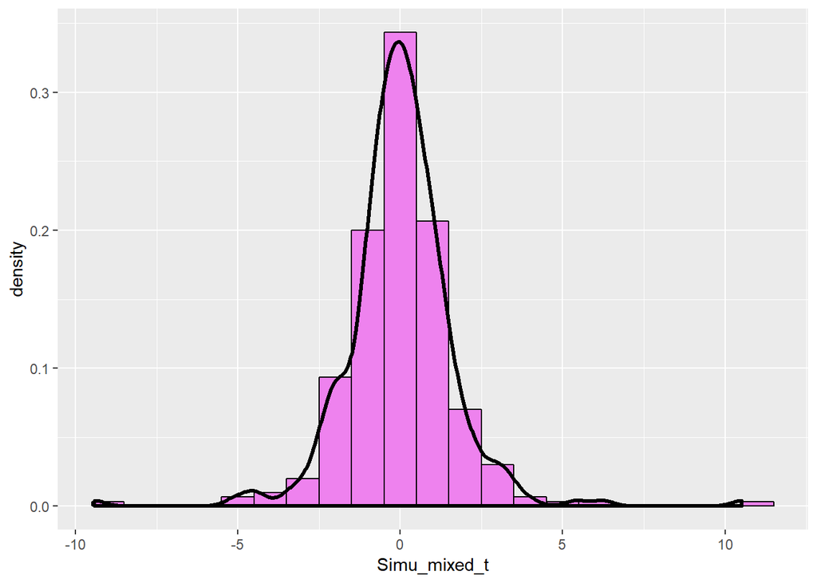

服从 t(100,2), t(100,4), t(100,6) 的各100个随机数组成的混合样本直方图

```r
set.seed(201904)
Simu_mixed_t <- NULL
for (i in 1:3){
  Simu_mixed_t  <- c(Simu_mixed_t , rt(100, 2*i)) #df = 2*i
}

ggplot(mapping =  aes(Simu_mixed_t )) +
  geom_histogram(mapping =  aes(y=..density..), binwidth = 1,
               color = 'black', fill = 'violet') +
  geom_density(size = 1.1, color = 'black')
```

### 4.4

由程序包DAAG中的数据集possum,

1). 利用函数hist(possum$age)作出负鼠年龄的直方图. 试选用两种不同的断点并作比较, 说明两图的不同之处;

2). 求出负鼠年龄变量的均值、标准差、中位数以及上下四分位数.

```r
library(DAAG)
```

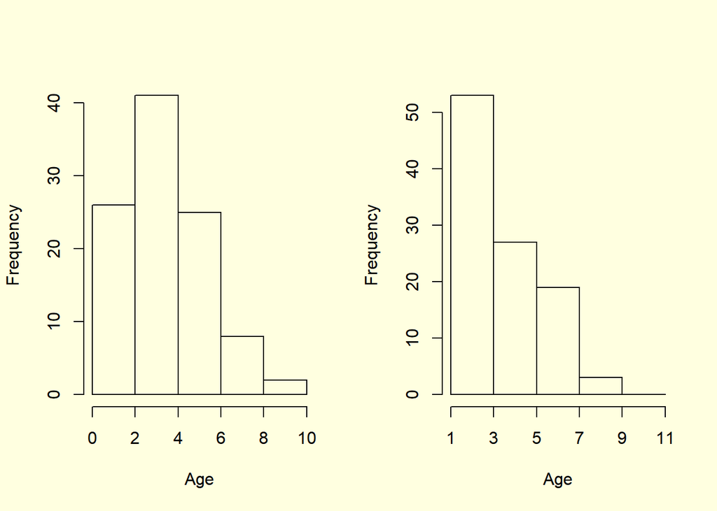

断点分别为0、2、4、6、8、10与1、3、5、7、9、11的直方图

```r
data(possum)

par(mfrow=c(1,2), bg = 'lightyellow')
breaks_1 <- seq(0, 10, 2)
breaks_2 <- breaks_1 + 1
hist(possum$age, breaks = breaks_1, xaxt = "n",
     main ='', xlab = 'Age')
axis(side = 1, labels =  breaks_1, at =  breaks_1)
hist(possum$age, breaks = breaks_2, xaxt = "n",
     main ='', xlab = 'Age')
axis(side = 1, labels =  breaks_2, at =  breaks_2)
```

```r
summary(possum$age,
        )[c('Mean', 'Median', '1st Qu.', '3rd Qu.')]
```

```
##     Mean   Median  1st Qu.  3rd Qu.
## 3.833333 3.000000 2.250000 5.000000
```

```r
sd(possum$age, na.rm = TRUE)
```

```
## [1] 1.909244
```

### 4.5

考虑程序包DAAG中的数据集tinting,

1). 获得变量tint和sex的列联表;

2). 在同一图上作出变量sex与tint的联合柱状图;

3). 作出age和it的散点图, 并进一步完成下面的操作:

1. 用函数lowness()作出拟合线;
2. 在图的两边加上更细小的刻度;
3. 在图的两边加上箱型图.

4). 作出age和it关于因子变量tint的条件散点图;

5). 作出age和it关于因子变量tint和sex的条件散点图;

6). 做出it与csoa的等高线图;

7). 使用matplot( )描述变量age, it和csoa.

#### 4.5.1

```r
data(tinting)
tint_sex <- as.data.frame(table(tinting$tint, tinting$sex))
colnames(tint_sex) <- c('tint', 'sex', 'Freq')
knitr::kable(tint_sex, format = 'pandoc', align = 'c',
             caption = '变量tint和sex的列联表')
```

变量tint和sex的列联表

| tint | sex | Freq |
| --- | --- | --- |
| no | f | 39 |
| lo | f | 26 |
| hi | f | 26 |
| no | m | 39 |
| lo | m | 26 |
| hi | m | 26 |

#### 4.5.2

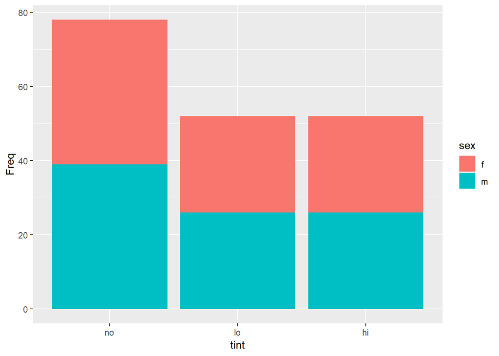

tinting数据集中sex与tint的联合柱状图

```r
ggplot(data = tint_sex, mapping = aes(x = tint, y = Freq, fill = sex)) +
  geom_bar(stat="identity", position = 'stack')
```

#### 4.5.3

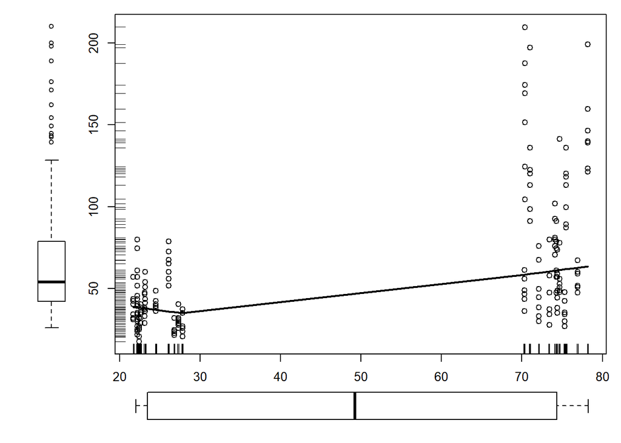

```r
library(DAAG)
layout(matrix(c(2, 1, 0, 3), 2, 2, byrow = T), widths = c(1, 5), heights = c(4, 1))
par(mar=c(0, 0.8, 1, 1))

plot(tinting$age, tinting$it)

lines(lowess(tinting$age, tinting$it), lwd = 2)

rug(side=2, jitter(tinting$it, 5))
rug(side=1, jitter(tinting$age, 5))

par(mar = c(1, 1, 1, 1))
boxplot(tinting$it, axes = FALSE)
par(mar = c(0, 1, 1, 1))
boxplot(tinting$age, horizontal = TRUE, axes = FALSE)
```

#### 4.5.3 Python

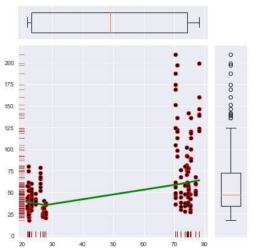

```python
import seaborn as sns
import matplotlib.pyplot as plt
from rpy2.robjects import r, pandas2ri

pandas2ri.activate()

r('library(DAAG)') #假设DAAG程序包已经下载到本地
tinting = r('data(tinting)')
tinting = r('tinting')

sns.set_style('darkgrid')
g = sns.JointGrid('age', 'it', data = tinting)
g.plot_joint(plt.scatter, color = 'k', s = 40, edgecolor = 'r')

plt.plot(r('lowess(tinting$age,tinting$it)')[0],
         r('lowess(tinting$age,tinting$it)')[1],
         color = 'g', linewidth = 3)

g.ax_marg_x.boxplot(x = tinting['age'], vert = False,
                    widths = 0.6)
g.ax_marg_y.boxplot(x = tinting['it'], widths = 0.6)

sns.rugplot(tinting['age'], color = 'darkred', axis = 'x',
            height = 0.03, alpha = 0.5)
sns.rugplot(tinting['it'], color = 'darkred', axis = 'y',
            height = 0.03, alpha = 0.5)

plt.show()
```